# Lab 3 - Regression Tree and Kaggle competition

## **Name and id:** Chen Harel 205566292

In this lab you will participate in a Kaggle competition:

https://www.kaggle.com/t/f1ada3d89cff40869257e1e9425af8bb

In this competition you will train and test a decision tree regressor while choosing how to preprocess the data and model's parameters.

First, click the link and join the competition.

using 'kaggle.json' file from the first lab, load the competition's data:

(remember to upload it to your environment)

You suppose to have 3 files:

```
Flight_Price_train_set.csv.zip
Flight_Price_test_set.csv.zip
Flight_Price_sample_submission.csv - which is an example file to your submission
```

```python
! mkdir ~/.kaggle
! cp kaggle.json ~/.kaggle/
! chmod 600 ~/.kaggle/kaggle.json
! kaggle competitions download -c decision-trees-lab-3
! unzip decision-trees-lab-3.zip
```

```
Downloading decision-trees-lab-3.zip to /content
  0% 0.00/4.97M [00:00<?, ?B/s]
100% 4.97M/4.97M [00:00<00:00, 85.9MB/s]
Archive:  decision-trees-lab-3.zip
  inflating: Flight_Price_sample_submission.csv
  inflating: Flight_Price_test_set.csv
  inflating: Flight_Price_train_set.csv
```

## Task 1:

Load the train set and decide how to preprocess it.

Think about missing values, redundant features, categorical values, normalization ect.

Note that the price column of the true labels was scaled between 0 and 1 using min max scaler

```python
import pandas as pd
import numpy as np
import matplotlib.pyplot as plt
from imblearn.over_sampling import SMOTE
import seaborn as sns
from sklearn.tree import DecisionTreeRegressor, plot_tree
from sklearn.model_selection import GridSearchCV, train_test_split
from sklearn.preprocessing import MinMaxScaler, LabelEncoder,OrdinalEncoder
from copy import deepcopy
import matplotlib.pyplot as plt

train_set = pd.read_csv('/content/Flight_Price_train_set.csv', index_col='index')
train_set.head(10)
```

| index | airline | flight | source_city | departure_time | stops | arrival_time | destination_city | class | duration | days_left | price |
| --- | --- | --- | --- | --- | --- | --- | --- | --- | --- | --- | --- |
| 179791 | Vistara | UK-876 | Hyderabad | Night | one | Morning | Chennai | Economy | 14.25 | 41 | 6287 |
| 94264 | GO_FIRST | G8-116 | Bangalore | Early_Morning | one | Night | Mumbai | Economy | 13.83 | 3 | 5177 |
| 140559 | Vistara | UK-738 | Kolkata | Evening | one | Night | Bangalore | Economy | 25.67 | 36 | 8111 |
| 213532 | Air_India | AI-665 | Delhi | Early_Morning | one | Morning | Bangalore | Business | 27.17 | 21 | 42457 |
| 6230 | Indigo | 6E-2097 | Delhi | Early_Morning | one | Afternoon | Mumbai | Economy | 7.58 | 32 | 2410 |
| 24656 | Indigo | 6E-2043 | Delhi | Afternoon | one | Evening | Kolkata | Economy | 4.17 | 27 | 4257 |
| 208126 | Vistara | UK-879 | Delhi | Evening | one | Night | Mumbai | Business | 5.33 | 15 | 45156 |
| 43333 | Vistara | UK-771 | Mumbai | Early_Morning | one | Morning | Delhi | Economy | 26.58 | 3 | 14028 |
| 189185 | Air_India | AI-430 | Chennai | Morning | one | Evening | Mumbai | Economy | 8.08 | 15 | 10643 |
| 199118 | Vistara | UK-822 | Chennai | Morning | one | Night | Kolkata | Economy | 13.00 | 15 | 15384 |

```python
# Cheking null values and types.
train_set.info()
```

```
<class 'pandas.core.frame.DataFrame'>
Int64Index: 210107 entries, 179791 to 185042
Data columns (total 11 columns):
 #   Column            Non-Null Count   Dtype
---  ------            --------------   -----
 0   airline           210107 non-null  object
 1   flight            210107 non-null  object
 2   source_city       210107 non-null  object
 3   departure_time    210107 non-null  object
 4   stops             210107 non-null  object
 5   arrival_time      210107 non-null  object
 6   destination_city  210107 non-null  object
 7   class             210107 non-null  object
 8   duration          210107 non-null  float64
 9   days_left         210107 non-null  int64
 10  price             210107 non-null  int64
dtypes: float64(1), int64(2), object(8)
memory usage: 19.2+ MB
```

```python
# Getting some description about categorial features.
train_set.describe(include=["object"])
```

|  | airline | flight | source_city | departure_time | stops | arrival_time | destination_city | class |
| --- | --- | --- | --- | --- | --- | --- | --- | --- |
| count | 210107 | 210107 | 210107 | 210107 | 210107 | 210107 | 210107 | 210107 |
| unique | 6 | 1552 | 6 | 6 | 3 | 6 | 6 | 2 |
| top | Vistara | UK-706 | Delhi | Morning | one | Night | Mumbai | Economy |
| freq | 89459 | 2269 | 42758 | 49491 | 175665 | 63848 | 41531 | 144426 |

```python
# Getting some description about numerical features.
train_set.describe().round(3)
```

|  | duration | days_left | price |
| --- | --- | --- | --- |
| count | 210107.000 | 210107.000 | 210107.000 |
| mean | 12.232 | 25.996 | 20941.686 |
| std | 7.196 | 13.577 | 22717.532 |
| min | 0.830 | 1.000 | 1105.000 |
| 25% | 6.830 | 14.000 | 4784.000 |
| 50% | 11.250 | 26.000 | 7439.000 |
| 75% | 16.170 | 38.000 | 42521.000 |
| max | 49.830 | 49.000 | 123071.000 |

```python
cat_columns = ['airline','flight','source_city','departure_time','stops','arrival_time','destination_city','class',]
num_columns = ['duration','days_left']
```

```python
# Encoding categorial values.

# df for Dataframe, labels = list of col labels
data = deepcopy(train_set)
def encoding(df,labels):
  for label in labels:
    le = LabelEncoder()
    new_col = le.fit_transform(df[label])
    df['encoded_'+label] = new_col
  return df

x = encoding(data,cat_columns)
x = x.drop(columns='price')
y = train_set.iloc[:,-1].values
y = y.reshape(-1,1)
scaler = MinMaxScaler()
y_scaled = scaler.fit_transform(y)
```

*Feature analyzation*

Inorder to check which features we prefer to use, I draw an heatmap to see correlation between each feature to the others.

Now because i want to predict the price of the ticket. we'll look at the row (or columns) of *'price'* As we can see, the result makes alot of sense:

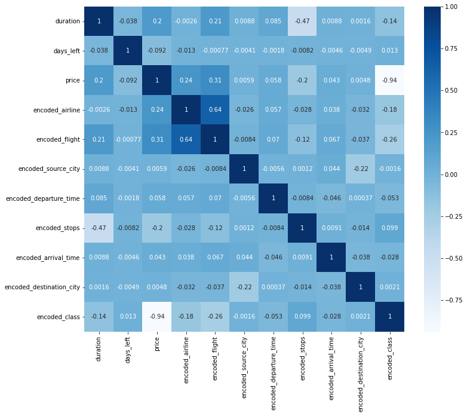

```python
# Finding Correlation between the features.
check_cor = encoding(train_set,cat_columns)
plt.figure(figsize=(12,10))
cor = check_cor.corr()
sns.heatmap(cor, annot=True, cmap=plt.cm.Blues)
plt.show()
```

## Task 2:

Engineer features by combining 2 or more features in non linear way. For example multiply the number of stops and duration

Create 2 new features by combining existing features. Add those features to your feature set.

```python
# Feature Engineering : Duration * Class
train_set['indulged'] = train_set['duration'] * train_set['class'].replace(['Economy','Business'], [1, 2])
train_set.head(10)
```

| index | airline | flight | source_city | departure_time | stops | arrival_time | destination_city | class | duration | days_left | price | encoded_airline | encoded_flight | encoded_source_city | encoded_departure_time | encoded_stops | encoded_arrival_time | encoded_destination_city | encoded_class | indulged |
| --- | --- | --- | --- | --- | --- | --- | --- | --- | --- | --- | --- | --- | --- | --- | --- | --- | --- | --- | --- | --- |
| 179791 | Vistara | UK-876 | Hyderabad | Night | one | Morning | Chennai | Economy | 14.25 | 41 | 6287 | 5 | 1511 | 3 | 5 | 0 | 4 | 1 | 1 | 14.25 |
| 94264 | GO_FIRST | G8-116 | Bangalore | Early_Morning | one | Night | Mumbai | Economy | 13.83 | 3 | 5177 | 2 | 925 | 0 | 1 | 0 | 5 | 5 | 1 | 13.83 |
| 140559 | Vistara | UK-738 | Kolkata | Evening | one | Night | Bangalore | Economy | 25.67 | 36 | 8111 | 5 | 1440 | 4 | 2 | 0 | 5 | 0 | 1 | 25.67 |
| 213532 | Air_India | AI-665 | Delhi | Early_Morning | one | Morning | Bangalore | Business | 27.17 | 21 | 42457 | 1 | 809 | 2 | 1 | 0 | 4 | 0 | 0 | 54.34 |
| 6230 | Indigo | 6E-2097 | Delhi | Early_Morning | one | Afternoon | Mumbai | Economy | 7.58 | 32 | 2410 | 3 | 120 | 2 | 1 | 0 | 0 | 5 | 1 | 7.58 |
| 24656 | Indigo | 6E-2043 | Delhi | Afternoon | one | Evening | Kolkata | Economy | 4.17 | 27 | 4257 | 3 | 100 | 2 | 0 | 0 | 2 | 4 | 1 | 4.17 |
| 208126 | Vistara | UK-879 | Delhi | Evening | one | Night | Mumbai | Business | 5.33 | 15 | 45156 | 5 | 1514 | 2 | 2 | 0 | 5 | 5 | 0 | 10.66 |
| 43333 | Vistara | UK-771 | Mumbai | Early_Morning | one | Morning | Delhi | Economy | 26.58 | 3 | 14028 | 5 | 1444 | 5 | 1 | 0 | 4 | 2 | 1 | 26.58 |
| 189185 | Air_India | AI-430 | Chennai | Morning | one | Evening | Mumbai | Economy | 8.08 | 15 | 10643 | 1 | 713 | 1 | 4 | 0 | 2 | 5 | 1 | 8.08 |
| 199118 | Vistara | UK-822 | Chennai | Morning | one | Night | Kolkata | Economy | 13.00 | 15 | 15384 | 5 | 1468 | 1 | 4 | 0 | 5 | 4 | 1 | 13.00 |

## Task 3:

Create decision tree for regression using sklearn.tree.DecisionTreeRegressor library. Select model's parameters: max_depth, ccp_alpha using sklearn.model_selection.GridSearchCV (https://scikit-learn.org/stable/modules/generated/sklearn.model_selection.GridSearchCV.html)

You can find information about those paremeters here:

https://scikit-learn.org/stable/modules/generated/sklearn.tree.DecisionTreeRegressor.html

Train the tree on the train set data.

```python
# After testing decided that without my feature i get better result
x = x.drop(['flight','airline','departure_time','stops','arrival_time','destination_city','class','encoded_flight','source_city'], axis=1)
```

```python
# implement here
params = {
    'max_depth':(3,7,13,22,27,33),
    'ccp_alpha':(0,5,1),
    'max_features':[6,7,8,9]
}

dtr = DecisionTreeRegressor()
clf = GridSearchCV(estimator = dtr,
                   param_grid = params,
                   scoring ='neg_mean_absolute_error',
                   cv = 5,
                   return_train_score = True)
```

```python
clf.fit(x, y_scaled)
```

```
GridSearchCV(cv=5, estimator=DecisionTreeRegressor(),
             param_grid={'ccp_alpha': (0, 5, 1),
                         'max_depth': (3, 7, 13, 22, 27, 33),
                         'max_features': [6, 7, 8, 9]},
             return_train_score=True, scoring='neg_mean_absolute_error')
```

```python
# Best estimator from grid search.
clf.best_estimator_
```

```
DecisionTreeRegressor(ccp_alpha=0, max_depth=33, max_features=9)
```

```python
# grid best estimator score (score = negative mean absolute error)
clf.best_score_
```

```
-0.010124612342467105
```

## Task 4:

Use the trained model to predict on the test set.

plot the selected tree using tree.plot_tree

Save the output predictions on a csv file to submit to the Kaggle competition. Name the file 'sample_submission', you have an example of it in a file named 'Flight_Price_sample_submission.csv'

Make sure to keep the ids same as they are in "Flight_Price_sample_submission.csv"

```python
# implement here


test_set = pd.read_csv('/content/Flight_Price_test_set.csv', index_col='index')
#test_set = test_set.drop(['flight'], axis=1)

x_test = encoding(test_set,cat_columns)
x_test = x_test.drop(['flight','airline','departure_time','stops','arrival_time','destination_city','class','encoded_flight','source_city'], axis=1)

dtr = DecisionTreeRegressor(ccp_alpha=0, max_depth=33, max_features=9)
dtr.fit(x,y_scaled)

prediction = dtr.predict(x_test)
sub = pd.read_csv('/content/Flight_Price_sample_submission.csv', index_col='index')
sub['price'] = prediction
sub.to_csv('/content/sample_submission.csv')
```

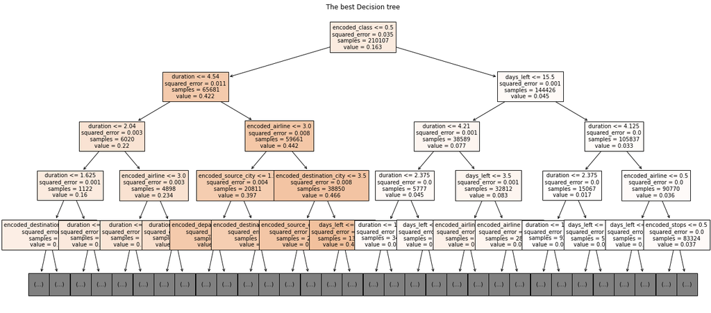

```python
plt.figure(figsize=(22,10))
plot_tree(clf.best_estimator_, filled=True,max_depth=4,fontsize=10,feature_names=x_test.columns)
plt.title("The best Decision tree")
plt.show()
```

## Task 5:

Convert the notebook into html:

1. Download the notebook by clicking the File tab
2. Upload it to this environment
3. Run the command:

```python
%%shell
jupyter nbconvert --to html Lab3.ipynb
```

```
[NbConvertApp] Converting notebook Lab3.ipynb to html
[NbConvertApp] Writing 652326 bytes to Lab3.html
```